# Even-moment closure at the $U_2$ level: structure, exactness, and performance

E. J. Paul

2026-05-28

Abstract

We extend the bump-on-tail moment-closure analysis from the $N=3$ (odd, $U_3$) level to the $N=2$ (even, $U_2$) level. The key structural difference is that the $M_0 = 1$ source term in the $n=1$ moment equation breaks the bilinear identity that made the $U_3$ per-mode closure parameter-free. Nevertheless, the exact per-mode formula $\beta(\xi_b) \equiv U_2/U_0 = \xi_b^2 - 1/Z'(\xi_b)$ can be applied directly in time-domain as $U_2 = U_0\,\beta(U_1/U_0)$, since $r_1 = U_1/U_0 = \xi_b$ exactly on any single eigenmode. This direct-$\beta$ closure recovers kinetic $\gamma_{\max}$ to machine precision across the full $(u_b/v_b,\varepsilon)$ grid and reproduces the correct time-domain trajectory under both eigenmode-aligned and generic initial conditions. The Padé $N=2$ linear closure has $+57\%$ overshoot at the canonical operating point and $+800\%$ at the marginal corner. The off-manifold diagnostic reveals why: the Padé linear approximation $\beta_{\rm Pad\'{e}} = a_0 + a_1\xi_b$ carries an $O(1)$ closure error at the kinetic $\xi_b$ value for all time, while the direct-$\beta$ error decays exponentially once the Langmuir mode dominates. Because $\beta$ is a function of a *single* complex input $r_1 = U_1/U_0$, a neural network at this level would only need to learn $\beta : \mathbb{C} \to \mathbb{C}$—and the exact Faddeeva evaluation already provides that without any training.

# Setup: the $N=2$ moment system

We retain the same cold-bulk + warm-Maxwellian-beam model from the $N=3$ analysis. Truncating at $N=2$ beam moments gives the four-dimensional state $y = (u, E, U_0, U_1)$ per Fourier mode $k$:
$$\begin{align}
\partial_t u &= -E,
\label{eq:u}\\
\partial_t E &= u - \varepsilon(u_bU_0 + U_1),
\label{eq:E}\\
\partial_t U_0 &= -iku_bU_0 - ik U_1,
\label{eq:U0}\\
\partial_t U_1 &= -iku_bU_1 - ik U_2 + M_0 E,
\label{eq:U1}
\end{align}$$
where $M_0 = 1$ and the closure problem is to specify $U_2$ from $(U_0, U_1)$.

#### Moment recurrence.

For a Maxwellian beam ($M_0=1$, $M_1=0$, $M_2=1/2$, …) the exact linearized recurrence on a mode at $\xi_b= (\omega-ku_b)/(kv_b)$ is
$$\begin{equation}
\label{eq:rec}
\xi_bU_n - U_{n+1} = n M_{n-1}\hat{\Phi}.
\end{equation}$$
Iterating from $U_0 = Z'(\xi_b)\hat{\Phi}$:
$$\begin{align}
U_1 &= \xi_bU_0 \qquad\text{(}n=0\text{, RHS}=0\text{ since }
M_{-1} = 0\text{)},\label{eq:U1exact}\\
U_2 &= \xi_bU_1 - M_0\hat{\Phi}= \xi_b^2 U_0 - \hat{\Phi}
\qquad\text{(}n=1\text{, RHS}=\hat{\Phi}\text{)}.
\label{eq:U2exact}
\end{align}$$
Equation [eq:U1exact] gives $r_1 \equiv U_1/U_0 = \xi_b$ exactly. Dividing [eq:U2exact] by $U_0$ and using $U_0/\hat{\Phi}= Z'(\xi_b)$:
$$\begin{equation}
\label{eq:beta}
\boxed{\beta(\xi_b) \equiv \frac{U_2}{U_0}
= \xi_b^2 - \frac{1}{Z'(\xi_b)}.}
\end{equation}$$
This is the exact per-mode closure ratio.

# Structural contrast with the $N=3$ case

The $N=3$ analog of [eq:beta] is $\alpha(\xi_b) = \xi_b^3 - \xi_b/Z'(\xi_b)$. There, iterating one step further gives $U_3 = \xi_bU_2$ (the $n=2$ RHS vanishes because $M_1=0$), producing the zero-parameter bilinear identity
$$\begin{equation}
\label{eq:bilinear}
\alpha(\xi_b)
= \frac{U_1}{U_0}\cdot\frac{U_2}{U_0}
= r_1 r_2.
\end{equation}$$
This identity exists only because $M_1 = 0$. At $N=2$, the $n=1$ recurrence has a nonzero source ($M_0 = 1$), so no such simplification is available and $\beta$ explicitly involves $Z'$.

At $N=3$ this created a tension: the bilinear identity was the correct per-mode closure but a *poor* off-manifold extension (cross-terms from a superposition of modes break it at $O(1)$). At $N=2$ the analogous tension is absent: because $r_1 = U_1/U_0 = \xi_b$ is the *only* available input ratio, applying $\beta(r_1)$ directly is both the exact on-mode formula and the natural off-manifold extension.

Table 1 summarises the two levels.

Structural comparison of $N=2$ and $N=3$ closures.

|  | $N=3$ ($U_3$ closure, odd) | $N=2$ ($U_2$ closure, even) |
| --- | --- | --- |
| Exact per-mode formula | $\alpha = \xi_b^3 - \xi_b/Z'(\xi_b)$ | $\beta = \xi_b^2 - 1/Z'(\xi_b)$ |
| Zero-parameter identity | $\alpha = r_1 r_2$ (bilinear) | none |
| NN input dimension | 4 reals ($r_1, r_2 \in \mathbb{C}$) | 2 reals ($r_1 \in \mathbb{C}$) |
| Inference map ($r\to\xi_b$) | non-trivial (Z’ entangled in $r_2$) | trivial: $r_1 = \xi_b$ |
| Off-manifold problem | cross-terms $O(1)$, NN needed | smoother transient, exact formula sufficient |

# Padé $N=2$ closure

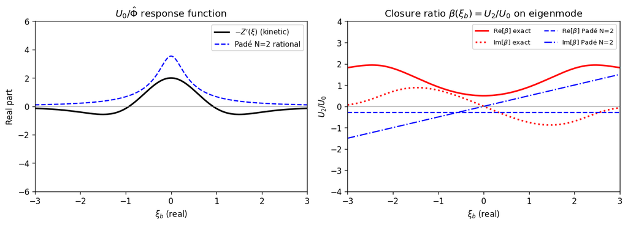

Left: kinetic response function $-Z'(\xi_b)$ (solid) vs Padé $N=2$ rational (dashed) along real $\xi_b$. Right: exact $\beta(\xi_b)$ (red, Re solid / Im dotted) vs Padé-implied linear $\beta$ (blue, Re dashed / Im dash-dot). The Padé rational overestimates the peak of $-Z'$ near $\xi_b=0$ by a factor of $\sim\!2$ and the linear $\beta$ does not approximate the smooth nonlinear exact $\beta$ for $|\xi_b|>0.5$.

# Dispersion results

The direct-$\beta$ dispersion is found by fixed-point iteration: given $\omega$, compute $\xi_b= (\omega - ku_b)/k$, set $U_2 = \beta(\xi_b) U_0$ (i.e. the closure coefficient vector $\mathbf{a} = [\beta(\xi_b),\, 0]$), solve the $4\times 4$ fluid eigenvalue problem, and repeat until convergence. At convergence the self-consistent $\xi_b$ satisfies $\beta(\xi_b) = U_2/U_0$ exactly, so the eigenvalue matches the kinetic root to numerical precision.

Table 2 gives $\gamma_{\max}$ overshoot at representative operating points.

$\gamma_{\max}$ relative overshoot vs kinetic from dispersion.

| $u_b/v_b$ | $\varepsilon$ | $\gamma_{\rm kin}$ | Padé $N=2$ | Direct $\beta$ |
| --- | --- | --- | --- | --- |
| 5.0 | 0.05 | $+0.17028$ | $+57\%$ | $0.00\%$ |
| 5.0 | 0.20 | $+0.28919$ | $+28\%$ | $0.00\%$ |
| 8.0 | 0.05 | $+0.19991$ | $+23\%$ | $0.00\%$ |
| 3.0 | 0.05 | $+0.11254$ | $+177\%$ | $0.00\%$ |

# Time-domain comparison

Figure 2 shows $|E(t)|$ at the canonical point $(u_b/v_b, \varepsilon, k) = (5, 0.05, 0.24)$ under two initial conditions: the kinetic Langmuir eigenvector projected onto the $N=2$ fluid state, and a generic $\delta E$ perturbation that excites all four fluid modes.

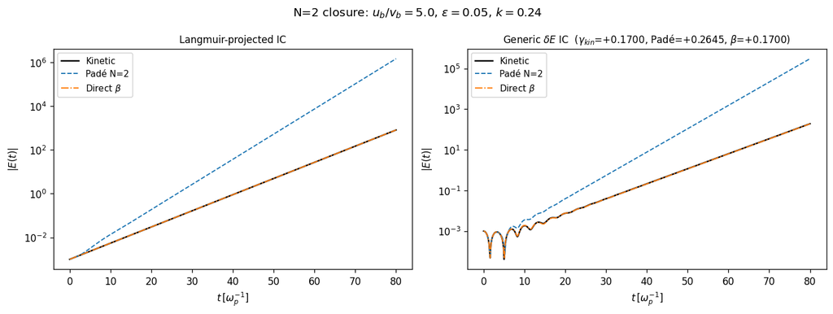

$|E(t)|$ for kinetic (black), Padé $N=2$ (blue dashed), and direct-$\beta$ (orange dash-dot) under Langmuir-projected (left) and generic $\delta E$ (right) ICs. Fitted $\gamma_{\rm eff}$: kinetic $+0.1700$, Padé $+0.2645$, direct-$\beta$ $+0.1700$.

The direct-$\beta$ trajectory lies on top of the kinetic reference for both ICs. Padé $N=2$ diverges from kinetic from the outset because its Langmuir-like eigenmode carries a $+55\%$ growth-rate error.

# Off-manifold diagnostic

To isolate closure quality from trajectory feedback we evaluate each closure on the *kinetic* moments and compare to the exact $\beta_{\rm kin}(t) = U_2^{\rm kin}/U_0^{\rm kin}$ (Figure 3).

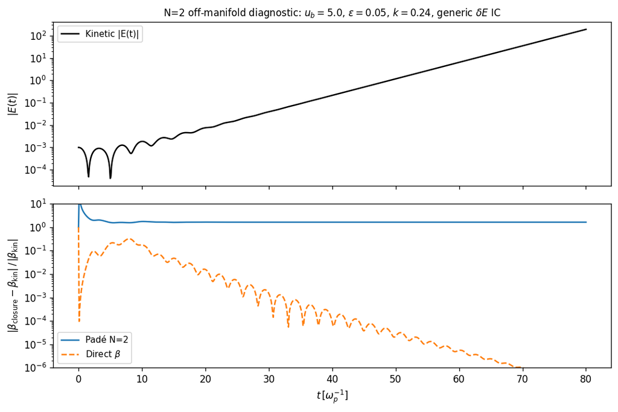

# Parameter sweep

Figure 4 shows $\log_{10}|\gamma_{\rm eff}/\gamma_{\rm kin} - 1|$ over the $(u_b/v_b, \varepsilon)$ grid from time-domain integration with a generic $\delta E$ IC.

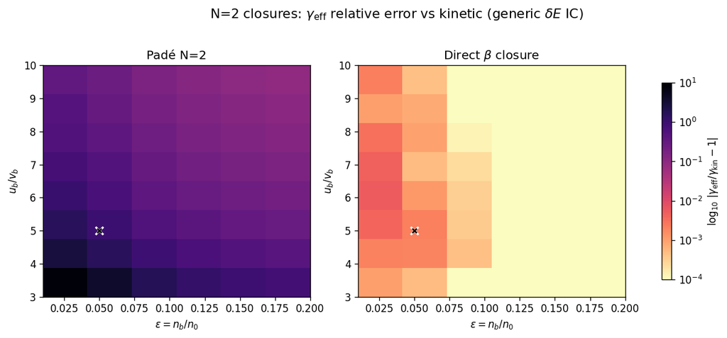

# Discussion

The $N=2$ even-moment analysis demonstrates that the absence of a bilinear identity does not prevent an exact time-domain closure: because the only available moment ratio is $r_1 = U_1/U_0 = \xi_b$ (trivially invertible), applying $\beta(r_1)$ directly via the Faddeeva function is both the exact on-mode formula and a well-behaved off-manifold extension.

This contrasts sharply with the $N=3$ situation. There, the bilinear identity $\alpha = r_1 r_2$ *was* the correct per-mode formula, but applying it in time-domain produced $O(1)$ off-manifold errors from cross-terms; a neural network was needed to find a better extension. At $N=2$ the direct-$\beta$ closure self-consistently avoids this problem: the single-ratio input space means there are no cross-terms to introduce, and the smooth analytic structure of $\beta$ provides a sufficiently accurate interpolation between multi-mode and single-mode regimes.

A neural network at $N=2$ level could in principle replace the Faddeeva call with a cheap inference step, but there is nothing to gain: the exact formula is already available analytically, and its off-manifold behavior is already superior to Padé $N=2$. The conclusion is that for *even* moment truncations the exact $\beta$ evaluation is the right closure; the interesting NN problem is restricted to odd-moment levels (or higher even levels where the general formula [eq:beta-general] requires a sum over several Maxwellian moments and the off-manifold behavior may again degrade).

#### General even-moment formula.

For completeness, the exact per-mode closure ratio for $U_{2m}$ is
$$\begin{equation}
\label{eq:beta-general}
\frac{U_{2m}}{U_0} = \xi_b^{2m}
-
\frac{1}{Z'(\xi_b)}\sum_{j=0}^{m-1}(2j+1)M_{2j}\,\xi_b^{2(m-1-j)},
\end{equation}$$
which for $m=1$ reduces to [eq:beta]. The odd counterpart is $U_{2m+1} = (U_1/U_0)\,U_{2m}$, the simple product that holds at $N=3$ and persists because every odd equation has $M_{2m} = 0$ on its RHS.